# DM_Assignment3_Part2

Duo Zhou

7/25/2020

### Select only numeric variables from Boston Housing dataset.

```r
dataPath <- "C:/Users/zd000/Desktop/MSCA/Data Mining/Assignments/week3/"
BH <-read.csv(paste(dataPath, 'BosHousing.csv', sep = '/'), header = TRUE)
# remove Categorical Variables, keeping only the numerical data
BH<-BH[,c(-4,-9)]
head(BH)
```

```
##      CRIM ZN INDUS   NOX    RM  AGE    DIS TAX PTRATIO      B LSTAT MEDV
## 1 0.00632 18  2.31 0.538 6.575 65.2 4.0900 296    15.3 396.90  4.98 24.0
## 2 0.02731  0  7.07 0.469 6.421 78.9 4.9671 242    17.8 396.90  9.14 21.6
## 3 0.02729  0  7.07 0.469 7.185 61.1 4.9671 242    17.8 392.83  4.03 34.7
## 4 0.03237  0  2.18 0.458 6.998 45.8 6.0622 222    18.7 394.63  2.94 33.4
## 5 0.06905  0  2.18 0.458 7.147 54.2 6.0622 222    18.7 396.90  5.33 36.2
## 6 0.02985  0  2.18 0.458 6.430 58.7 6.0622 222    18.7 394.12  5.21 28.7
```

### Splitting the data into 70% train and 30% test as well as Scaling the data.

```r
set.seed(12345)
train_ind <- sample(1:nrow(BH),as.integer(nrow(BH)*0.7),replace=FALSE)
BH.train<-BH[train_ind,]
BH.test<-BH[-train_ind,]
BH.train.scal<-scale(BH.train)
BH.test.scal<-scale(BH.test)
```

### performing PCA on Training set

```r
PCA.train<-prcomp(BH.train.scal,center = TRUE,scale. = TRUE)
summary(PCA.train)
```

```
## Importance of components:
##                           PC1    PC2     PC3     PC4     PC5     PC6    PC7
## Standard deviation     2.4442 1.2532 1.05758 0.89860 0.82177 0.69643 0.6312
## Proportion of Variance 0.4978 0.1309 0.09321 0.06729 0.05628 0.04042 0.0332
## Cumulative Proportion  0.4978 0.6287 0.72191 0.78920 0.84547 0.88589 0.9191
##                            PC8     PC9    PC10    PC11    PC12
## Standard deviation     0.49903 0.45896 0.43736 0.42167 0.37696
## Proportion of Variance 0.02075 0.01755 0.01594 0.01482 0.01184
## Cumulative Proportion  0.93985 0.95740 0.97334 0.98816 1.00000
```

Calculating Porportion of Variance explained by each Principal Component

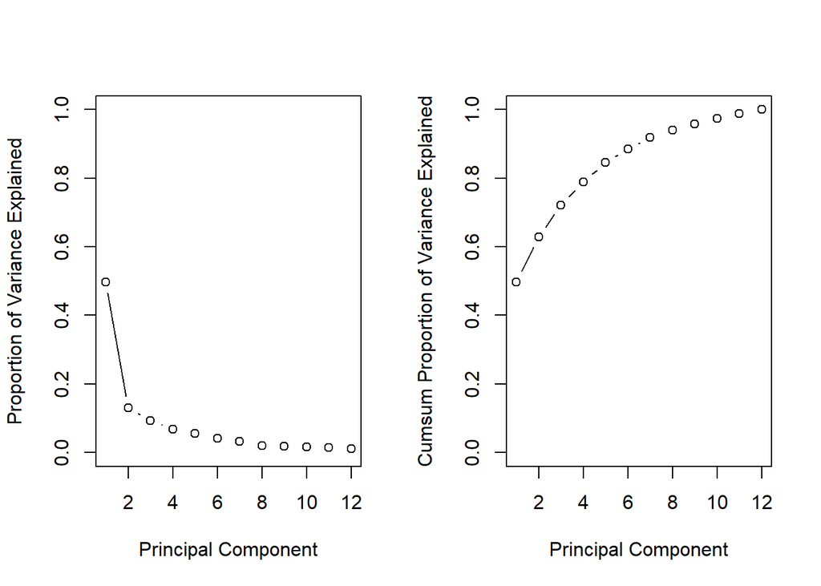

```r
pve<-PCA.train$sdev^2/sum(PCA.train$sdev^2)
par(mfrow=c(1,2))
plot(pve,xlab="Principal Component",ylab="Proportion of Variance Explained",ylim=c(0,1),
type="b")
plot(cumsum(pve),xlab="Principal Component",ylab="Cumsum Proportion of Variance Explained",ylim=c(0,1),
type="b")
```

```r
cumsum(pve)
```

```
##  [1] 0.4978276 0.6287033 0.7219092 0.7891990 0.8454749 0.8858925 0.9190949
##  [8] 0.9398478 0.9574013 0.9733417 0.9881587 1.0000000
```

From the cumsum(pve) plot, there is no obvious elbow to help identifying number of PCs to retain. We pick the first 5 principal components, which cover about 85% of total variance explained.

Biplot of PC2 vs. PC1

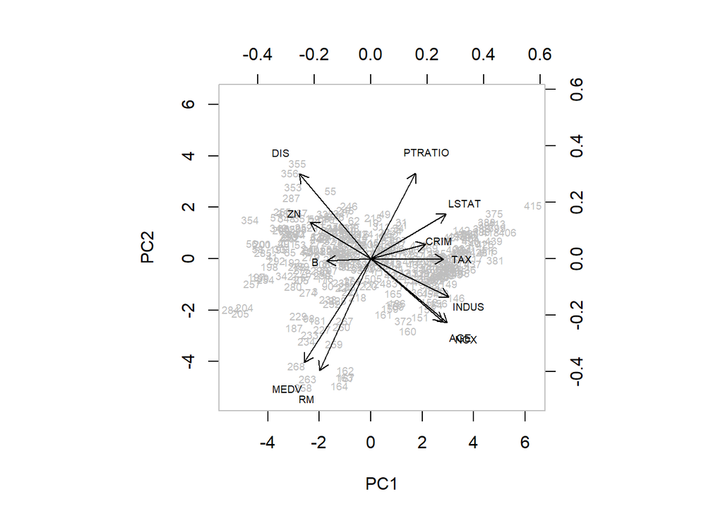

```r
biplot(PCA.train,choices=c(1,2),scale=0,cex=0.6,col=c(8,1))
```

Based on the Biplot of PC2 vs. PC1, PC1 covers a lot of the correlated census variables. Since they are highly correlated, we can say PC1 is the general census component. PC2 focuses more on the education level, income level, average house size and location of the community. We can call PC2 economic status component.

Biplot of PC3 vs. PC1

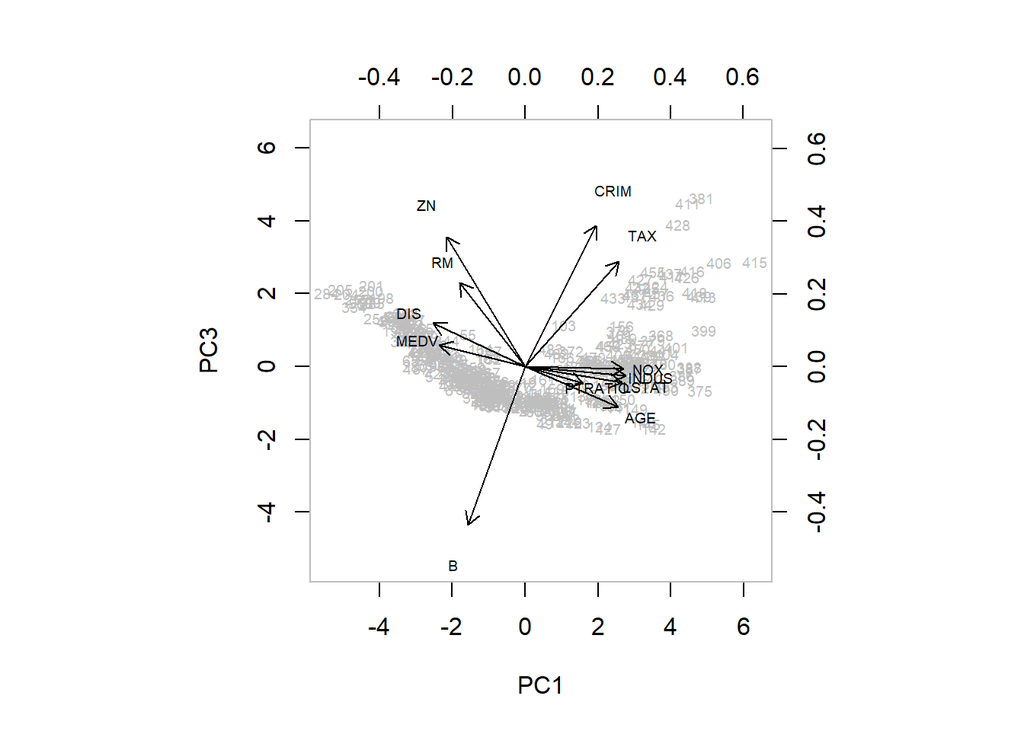

```r
biplot(PCA.train,choices=c(1,3),scale=0,cex=0.6,col=c(8,1))
```

PC3 is clearly focuses on crime rate, racial demographics and tax.

Biplot of PC4 vs. PC1

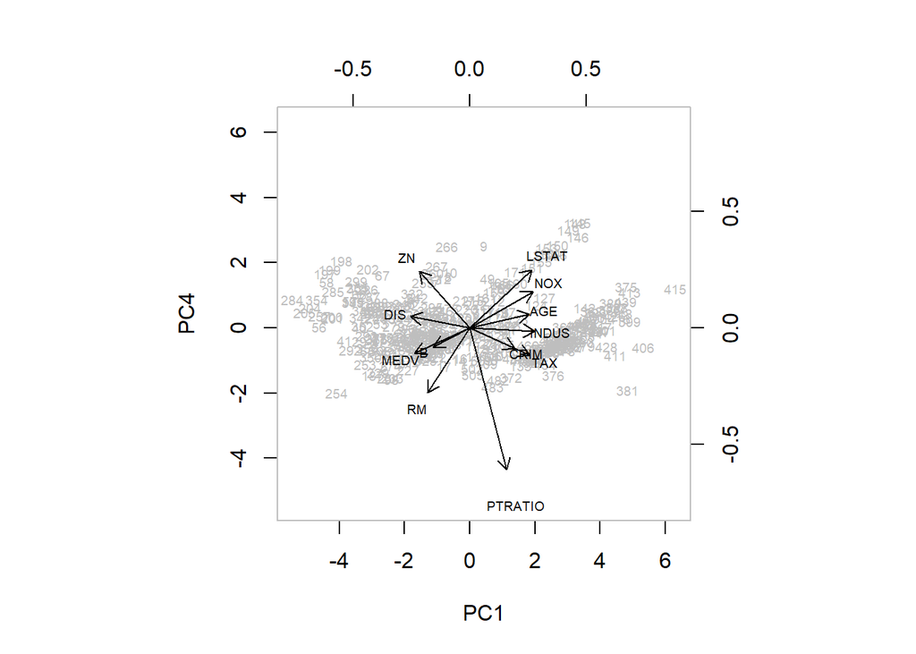

```r
biplot(PCA.train,choices=c(1,4),scale=0,cex=0.6,col=c(8,1))
```

PC4 focuses on the education status.

Biplot of PC5 vs. PC1

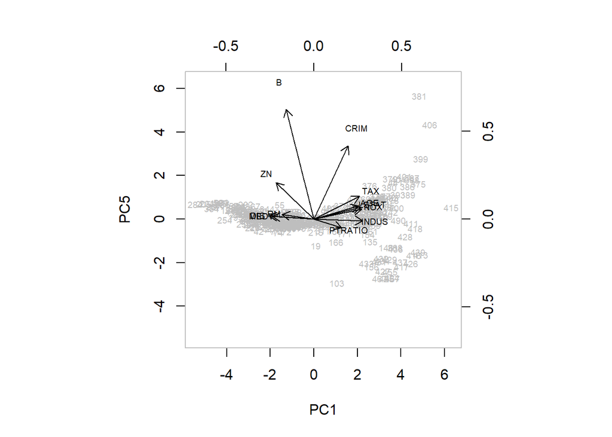

```r
biplot(PCA.train,choices=c(1,5),scale=0,cex=0.6,col=c(8,1))
```

Again, PC5 focuses on crime and racial demographics similar to PC3.

### Checking the Orthogonality of Loadings

```r
round(t(PCA.train$rotation)%*%PCA.train$rotation,5)
```

```
##      PC1 PC2 PC3 PC4 PC5 PC6 PC7 PC8 PC9 PC10 PC11 PC12
## PC1    1   0   0   0   0   0   0   0   0    0    0    0
## PC2    0   1   0   0   0   0   0   0   0    0    0    0
## PC3    0   0   1   0   0   0   0   0   0    0    0    0
## PC4    0   0   0   1   0   0   0   0   0    0    0    0
## PC5    0   0   0   0   1   0   0   0   0    0    0    0
## PC6    0   0   0   0   0   1   0   0   0    0    0    0
## PC7    0   0   0   0   0   0   1   0   0    0    0    0
## PC8    0   0   0   0   0   0   0   1   0    0    0    0
## PC9    0   0   0   0   0   0   0   0   1    0    0    0
## PC10   0   0   0   0   0   0   0   0   0    1    0    0
## PC11   0   0   0   0   0   0   0   0   0    0    1    0
## PC12   0   0   0   0   0   0   0   0   0    0    0    1
```

### Checking the Orthogonality of Scores

```r
round(cor(PCA.train$x),5)
```

```
##      PC1 PC2 PC3 PC4 PC5 PC6 PC7 PC8 PC9 PC10 PC11 PC12
## PC1    1   0   0   0   0   0   0   0   0    0    0    0
## PC2    0   1   0   0   0   0   0   0   0    0    0    0
## PC3    0   0   1   0   0   0   0   0   0    0    0    0
## PC4    0   0   0   1   0   0   0   0   0    0    0    0
## PC5    0   0   0   0   1   0   0   0   0    0    0    0
## PC6    0   0   0   0   0   1   0   0   0    0    0    0
## PC7    0   0   0   0   0   0   1   0   0    0    0    0
## PC8    0   0   0   0   0   0   0   1   0    0    0    0
## PC9    0   0   0   0   0   0   0   0   1    0    0    0
## PC10   0   0   0   0   0   0   0   0   0    1    0    0
## PC11   0   0   0   0   0   0   0   0   0    0    1    0
## PC12   0   0   0   0   0   0   0   0   0    0    0    1
```

### Train Test Validation

Let’s first take a look at the square of the correlation between original data and data calculated using the matrix multiplication of loading and scores of the first 5 PCs. In other word, let’s look at r square. We can compare the R^2 between train and test data.

```r
PCA.test<-predict(PCA.train,newdata=BH.test.scal)
## comparison of correlation
cor.train<-round(cor(as.vector(BH.train.scal),
as.vector(PCA.train$x[,1:5]%*%t(PCA.train$rotation)[1:5,]))^2,2)
cor.test<-round(cor(as.vector(scale(BH.test.scal)),
as.vector(PCA.test[,1:5]%*%t(PCA.train$rotation)[1:5,]))^2,2)

rbind(R.Square.Train=cor.train,R.Square.Test=cor.test)
```

```
##                [,1]
## R.Square.Train 0.85
## R.Square.Test  0.83
```

The we can compare the proportion of varaince explained.

```r
ve<-c(var(PCA.test[,1]),var(PCA.test[,2]),var(PCA.test[,3]),
var(PCA.test[,4]),var(PCA.test[,5]),var(PCA.test[,6]),
var(PCA.test[,7]),var(PCA.test[,8]),var(PCA.test[,9]),var(PCA.test[,10]),
var(PCA.test[,11]),var(PCA.test[,12]))

ve.total<-sum(ve)
pve.test<-sort(ve,decreasing = TRUE)/ve.total
per.diff<- abs(pve-pve.test)/pve
rbind(PVE.Train=pve, PVE.TEST=pve.test, Percent.Diff=per.diff)
```

```
##                    [,1]      [,2]       [,3]       [,4]       [,5]       [,6]
## PVE.Train    0.49782758 0.1308757 0.09320590 0.06728978 0.05627597 0.04041754
## PVE.TEST     0.50639018 0.1114219 0.09914485 0.06954003 0.04932416 0.04533745
## Percent.Diff 0.01719993 0.1486431 0.06371857 0.03344119 0.12353063 0.12172705
##                    [,7]       [,8]       [,9]       [,10]      [,11]
## PVE.Train    0.03320240 0.02075291 0.01755353 0.015940371 0.01481696
## PVE.TEST     0.03375821 0.02230620 0.01992693 0.015992800 0.01502844
## Percent.Diff 0.01674006 0.07484670 0.13520907 0.003289023 0.01427288
##                    [,12]
## PVE.Train    0.011841326
## PVE.TEST     0.011828800
## Percent.Diff 0.001057868
```

The R^2 and PVE values are not very different between the test and training PCAs. The principal component analysis is stable and produces good fit.

### Loading Rotation

Rotate the loadings using varimax

```r
rotated.loading<-varimax(PCA.train$rotation[,1:5])
rotated.loading
```

```
## $loadings
##
## Loadings:
##         PC1    PC2    PC3    PC4    PC5
## CRIM                   0.752         0.116
## ZN      -0.393         0.338  0.434
## INDUS    0.365
## NOX      0.440                0.181
## RM             -0.686  0.158
## AGE      0.450
## DIS     -0.504  0.103
## TAX      0.135         0.490        -0.119
## PTRATIO -0.126         0.162 -0.853
## B                                    0.978
## LSTAT    0.151  0.460         0.122
## MEDV           -0.546         0.126
##
##                  PC1   PC2   PC3   PC4   PC5
## SS loadings    1.000 1.000 1.000 1.000 1.000
## Proportion Var 0.083 0.083 0.083 0.083 0.083
## Cumulative Var 0.083 0.167 0.250 0.333 0.417
##
## $rotmat
##             [,1]        [,2]       [,3]       [,4]        [,5]
## [1,]  0.72727894  0.48778117  0.3493195 -0.2624186 -0.20554138
## [2,] -0.63268518  0.70051729  0.1005492 -0.3144193 -0.00392238
## [3,] -0.25942130 -0.23763009  0.7261576  0.2315827 -0.54341255
## [4,]  0.05728872  0.46312364 -0.1713092  0.8629005 -0.09105182
## [5,]  0.01390678  0.01983689  0.5578657  0.1845244  0.80879523
```

Biplot of PC2 vs. PC1

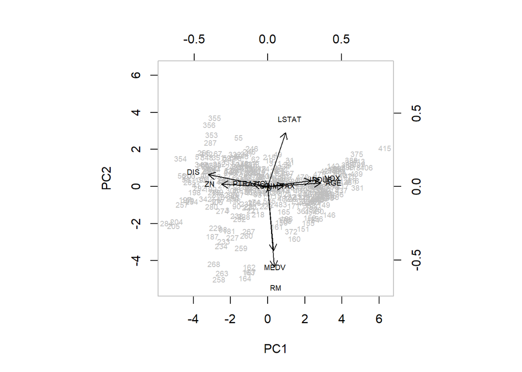

```r
biplot(PCA.train$x,rotated.loading$loadings[,c(1,2)],cex=0.6,col=c(8,1))
```

Based on the rotated loading plot, it is clear that economic status variables (LSTAT, MEDV) have the most impact on PC2 and PC1 is largely impacted by all of the other census variables. With or without rotation, PC2 is a clear indicator of economic (Income) status.

Biplot of PC3 vs. PC1

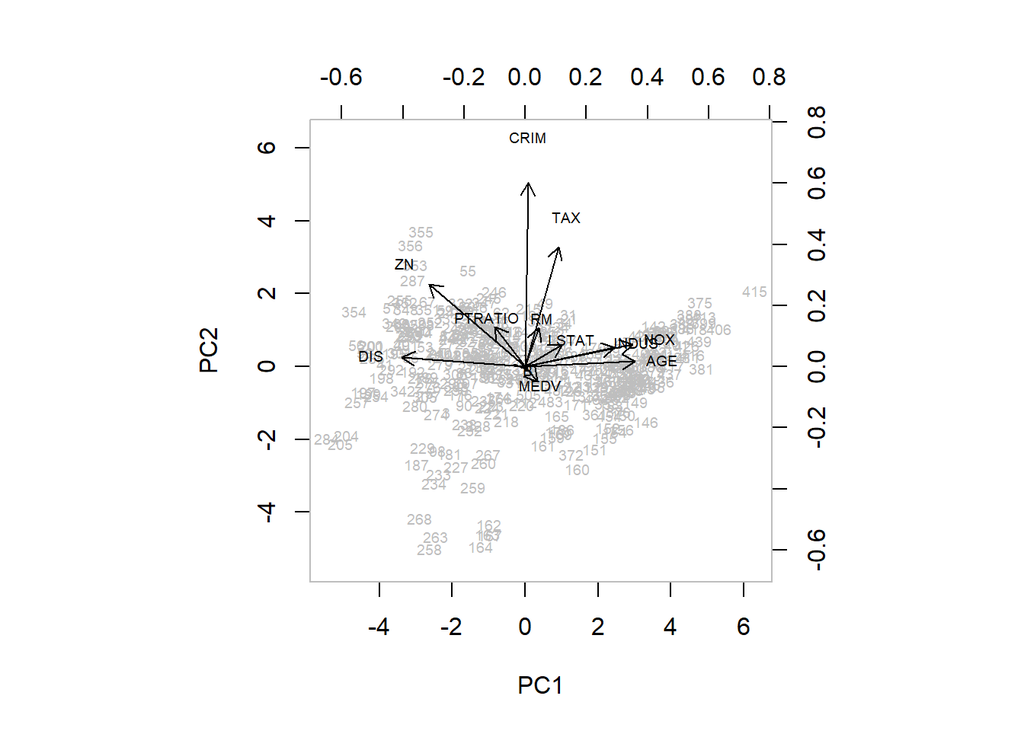

```r
biplot(PCA.train$x,rotated.loading$loadings[,c(1,3)],cex=0.6,col=c(8,1))
```

Similar to pre-rotation plot, PC3 focuses on crime rate and property tax, which implies that PC3 is a good indicator on crimes and tax.

After applying PCA on the numerical variables of Boston Housing data set, we are able to reduce the number of components from 12 to 5. Although the first principal component clustered many correlated census data, we can still exact useful insights on PC2, PC3 and PC4. The use of PCA on this dataset is a success.